```python
# Set up packages for lecture. Don't worry about understanding this code,
# but make sure to run it if you're following along.
import numpy as np
import babypandas as bpd

import matplotlib.pyplot as plt
plt.style.use('ggplot')

np.set_printoptions(threshold=20, precision=2, suppress=True)
import pandas as pd
pd.set_option("display.max_rows", 7)
pd.set_option("display.max_columns", 8)
pd.set_option("display.precision", 2)
```

# Lecture 5 – More Querying and GroupBy

## DSC 10, Spring 2023

### Announcements

- Lab 1 is due on **Saturday at 11:59PM**.
- Homework 1 is due on **Tuesday at 11:59PM**.
  - Do Lab 1 before Homework 1.
  - [Avoid submission errors](https://dsc10.com/syllabus/#submission-errors).
- Discussion 2 is today, and we'll be covering old exam problems on this week's material.
  - You must be present when attendance is taken in discussion to get credit, even if you have a conflicting class.

### Agenda

- Recap: Queries.
- Queries with multiple conditions.
- GroupBy.
- Extra practice, including challenge problems.

#### Don't forget about these resources!

- [DSC 10 Reference Sheet 📌](https://drive.google.com/file/d/1ky0Np67HS2O4LO913P-ing97SJG0j27n/view).
- [`babypandas` notes](https://notes.dsc10.com).
- [`babypandas` documentation](https://babypandas.readthedocs.io/en/latest/index.html).
- [The Resources tab of the course website](https://dsc10.com/resources/).

### You belong here! 🫂

- We're moving *very* quickly in this class.
- This may be the first time you're ever writing code, and you may question whether or not you belong in this class, or if data science is for you.
- We promise, no matter what your prior experience is, **the answer is yes, you belong!**
  - Watch: [🎥 Developing a Growth Mindset with Carol Dweck](https://www.youtube.com/watch?v=hiiEeMN7vbQ).
- Please come to office hours (see the schedule [here](https://dsc10.com/calendar)) and post on Ed for help – we're here to make sure you succeed in this course.

### About the Data: Get It Done service requests 👷

[figure not shown]

Recall, the `requests` DataFrame contains a summary of all service requests so far this year, broken down by neighborhood and service.

```python
requests = bpd.read_csv('data/get-it-done-requests.csv')
requests = requests.assign(total=requests.get('closed') + requests.get('open'))
requests
```

|  | neighborhood | service | closed | open | total |
| --- | --- | --- | --- | --- | --- |
| 0 | Balboa Park | Dead Animal | 11 | 0 | 11 |
| 1 | Balboa Park | Development Services - Code Enforcement | 2 | 0 | 2 |
| 2 | Balboa Park | Encampment | 215 | 20 | 235 |
| ... | ... | ... | ... | ... | ... |
| 1418 | Via De La Valle | Pothole | 11 | 7 | 18 |
| 1419 | Via De La Valle | Sidewalk Repair Issue | 0 | 1 | 1 |
| 1420 | Via De La Valle | Street Sweeping | 1 | 0 | 1 |

1421 rows × 5 columns

## Recap: Queries

### What is a query? 🤔

- A "query" is code that extracts rows from a DataFrame for which certain condition(s) are true.
- We often use queries to *filter* DataFrames so that they only contain the rows that satisfy the conditions stated in our questions.

### Comparison operators

There are several types of comparisons we can make.

| symbol | meaning |
| --- | --- |
| `==` | equal to |
| `!=` | not equal to |
| `<` | less than |
| `<=` | less than or equal to |
| `>` | greater than |
| `>=` | greater than or equal to |

```python
5 == 6
```

```
False
```

```python
type(5 == 6)
```

```
bool
```

```python
9 + 10 < 21
```

```
True
```

```python
'zebra' == 'zeb' + 'ra'
```

```
True
```

### How do we query a DataFrame?

To select only certain rows of `requests`:

1. Make a sequence (list/array/Series) of `True`s (keep) and `False`s (toss), usually by making a comparison.
2. Then pass it into `requests[sequence_goes_here]`.

```python
requests
```

|  | neighborhood | service | closed | open | total |
| --- | --- | --- | --- | --- | --- |
| 0 | Balboa Park | Dead Animal | 11 | 0 | 11 |
| 1 | Balboa Park | Development Services - Code Enforcement | 2 | 0 | 2 |
| 2 | Balboa Park | Encampment | 215 | 20 | 235 |
| ... | ... | ... | ... | ... | ... |
| 1418 | Via De La Valle | Pothole | 11 | 7 | 18 |
| 1419 | Via De La Valle | Sidewalk Repair Issue | 0 | 1 | 1 |
| 1420 | Via De La Valle | Street Sweeping | 1 | 0 | 1 |

1421 rows × 5 columns

```python
# A Boolean Series.
requests.get('closed') > 5
```

```
0        True
1       False
2        True
        ...
1418     True
1419    False
1420    False
Name: closed, Length: 1421, dtype: bool
```

```python
# A query.
requests[requests.get('closed') > 5]
```

|  | neighborhood | service | closed | open | total |
| --- | --- | --- | --- | --- | --- |
| 0 | Balboa Park | Dead Animal | 11 | 0 | 11 |
| 2 | Balboa Park | Encampment | 215 | 20 | 235 |
| 3 | Balboa Park | Environmental Services Code Compliance | 8 | 1 | 9 |
| ... | ... | ... | ... | ... | ... |
| 1413 | Uptown | Waste on Private Property | 40 | 2 | 42 |
| 1414 | Uptown | Weed Cleanup | 21 | 3 | 24 |
| 1418 | Via De La Valle | Pothole | 11 | 7 | 18 |

920 rows × 5 columns

## Example 5: Which neighborhood has the most `'Pothole'` requests? 🕳

**Key concept**: Querying.

### Strategy

1. Query to extract a DataFrame of just the `'Pothole'` requests.
2. Sort by `'total'` in descending order.
3. Extract the first element from the `'neighborhood'` column.

```python
# This DataFrame only contains rows where the 'service' is 'Pothole'!
only_potholes = requests[requests.get('service') == 'Pothole']
only_potholes
```

|  | neighborhood | service | closed | open | total |
| --- | --- | --- | --- | --- | --- |
| 12 | Balboa Park | Pothole | 70 | 8 | 78 |
| 40 | Barrio Logan | Pothole | 111 | 9 | 120 |
| 67 | Black Mountain Ranch | Pothole | 19 | 1 | 20 |
| ... | ... | ... | ... | ... | ... |
| 1366 | University | Pothole | 712 | 249 | 961 |
| 1396 | Uptown | Pothole | 513 | 87 | 600 |
| 1418 | Via De La Valle | Pothole | 11 | 7 | 18 |

56 rows × 5 columns

```python
# You can space your code out like this if needed.
(
    only_potholes
    .sort_values('total', ascending=False)
    .get('neighborhood')
    .iloc[0]
)
```

```
'Clairemont Mesa'
```

### What if the condition isn't satisfied?

```python
requests[requests.get('service') == 'Car Maintenance']
```

|  | neighborhood | service | closed | open | total |
| --- | --- | --- | --- | --- | --- |

### Concept Check ✅ – Answer at cc.dsc10.com

Which expression below evaluates to **the total number of service requests in the `'Downtown'` neighborhood**?

A. `requests[requests.get('neighborhood') == 'Downtown'].get('total').sum()`

B. `requests.get('total').sum()[requests.get('neighborhood') == 'Downtown']`

C. `requests['Downtown'].get('total').sum()`

D. More than one of the above.

```python
...
```

```
Ellipsis
```

### Activity 🚘

**Question**: What is the most commonly requested service in the `'University'` neighborhood (near UCSD)?

Write one line of code that evaluates to the answer.

```python
...
```

```
Ellipsis
```

## Example 6: How many service requests were for `'Pothole'` or `'Dead Animal'`?

**Key concept**: Queries with multiple conditions.

### Multiple conditions

- To write a query with multiple conditions, use `&` for "and" and `|` for "or".
  - `&`: All conditions must be true.
  - `|`: At least one condition must be true.
- **You must use `(`parentheses`)` around each condition!**
- 🚨 Don't use the Python keywords `and` and `or` here! They do not behave as you'd want.
  - See [BPD 10.3](https://notes.dsc10.com/02-data_sets/querying.html#multiple-conditions) for an explanation.

```python
requests[(requests.get('service') == 'Pothole') | (requests.get('service') == 'Dead Animal')]
```

|  | neighborhood | service | closed | open | total |
| --- | --- | --- | --- | --- | --- |
| 0 | Balboa Park | Dead Animal | 11 | 0 | 11 |
| 12 | Balboa Park | Pothole | 70 | 8 | 78 |
| 28 | Barrio Logan | Dead Animal | 2 | 0 | 2 |
| ... | ... | ... | ... | ... | ... |
| 1396 | Uptown | Pothole | 513 | 87 | 600 |
| 1415 | Via De La Valle | Dead Animal | 1 | 0 | 1 |
| 1418 | Via De La Valle | Pothole | 11 | 7 | 18 |

109 rows × 5 columns

```python
# You can add line breaks within brackets or parentheses.
requests[(requests.get('service') == 'Pothole') |
         (requests.get('service') == 'Dead Animal')]
```

|  | neighborhood | service | closed | open | total |
| --- | --- | --- | --- | --- | --- |
| 0 | Balboa Park | Dead Animal | 11 | 0 | 11 |
| 12 | Balboa Park | Pothole | 70 | 8 | 78 |
| 28 | Barrio Logan | Dead Animal | 2 | 0 | 2 |
| ... | ... | ... | ... | ... | ... |
| 1396 | Uptown | Pothole | 513 | 87 | 600 |
| 1415 | Via De La Valle | Dead Animal | 1 | 0 | 1 |
| 1418 | Via De La Valle | Pothole | 11 | 7 | 18 |

109 rows × 5 columns

### The `&` and `|` operators work element-wise!

```python
(requests.get('service') == 'Pothole')
```

```
0       False
1       False
2       False
        ...
1418     True
1419    False
1420    False
Name: service, Length: 1421, dtype: bool
```

```python
(requests.get('service') == 'Dead Animal')
```

```
0        True
1       False
2       False
        ...
1418    False
1419    False
1420    False
Name: service, Length: 1421, dtype: bool
```

```python
(requests.get('service') == 'Pothole') | (requests.get('service') == 'Dead Animal')
```

```
0        True
1       False
2       False
        ...
1418     True
1419    False
1420    False
Name: service, Length: 1421, dtype: bool
```

### Original Question: How many service requests were for `'Pothole'` or `'Dead Animal'`?

```python
requests[(requests.get('service') == 'Pothole') |
         (requests.get('service') == 'Dead Animal')].get('total').sum()
```

```
18512
```

### Concept Check ✅ – Answer at cc.dsc10.com

Each of the following questions can be answered by querying the `requests` DataFrame.

1. Which neighborhood had the most `'Street Flooded'` requests?
2. In the `'Kearny Mesa'` neighborhood, how many different types of services have open requests?
3. How many requests have been closed in the `'La Jolla'` neighborhood?

How many of the questions above **require** the query to have **multiple conditions**?

A. 0 B. 1 C. 2 D. 3

**Bonus**: Try to write code to answer each question.

```python
...
```

```
Ellipsis
```

### Aside: Using `.take` to select rows by position

- Querying allows us to select rows that satisfy a certain *condition*.
- We can also select rows in specific *positions* with `.take([list_of_integer_positions])`. This keeps only the rows whose positions are in the specified list.
  - This is analogous to using `.iloc[]` on a Series.
  - It's rare to need to select rows by integer position. Querying is **far** more useful.

```python
requests
```

|  | neighborhood | service | closed | open | total |
| --- | --- | --- | --- | --- | --- |
| 0 | Balboa Park | Dead Animal | 11 | 0 | 11 |
| 1 | Balboa Park | Development Services - Code Enforcement | 2 | 0 | 2 |
| 2 | Balboa Park | Encampment | 215 | 20 | 235 |
| ... | ... | ... | ... | ... | ... |
| 1418 | Via De La Valle | Pothole | 11 | 7 | 18 |
| 1419 | Via De La Valle | Sidewalk Repair Issue | 0 | 1 | 1 |
| 1420 | Via De La Valle | Street Sweeping | 1 | 0 | 1 |

1421 rows × 5 columns

```python
requests.take([1, 3, 5])
```

|  | neighborhood | service | closed | open | total |
| --- | --- | --- | --- | --- | --- |
| 1 | Balboa Park | Development Services - Code Enforcement | 2 | 0 | 2 |
| 3 | Balboa Park | Environmental Services Code Compliance | 8 | 1 | 9 |
| 5 | Balboa Park | Graffiti - Public | 343 | 25 | 368 |

```python
requests.get('service').iloc[[1, 3, 5]]
```

```
1    Development Services - Code Enforcement
3     Environmental Services Code Compliance
5                          Graffiti - Public
Name: service, dtype: object
```

```python
requests.take(np.arange(5))
```

|  | neighborhood | service | closed | open | total |
| --- | --- | --- | --- | --- | --- |
| 0 | Balboa Park | Dead Animal | 11 | 0 | 11 |
| 1 | Balboa Park | Development Services - Code Enforcement | 2 | 0 | 2 |
| 2 | Balboa Park | Encampment | 215 | 20 | 235 |
| 3 | Balboa Park | Environmental Services Code Compliance | 8 | 1 | 9 |
| 4 | Balboa Park | Graffiti - Code Enforcement | 2 | 1 | 3 |

## Example 7: Which neighborhood had the most requests?

**Key concept**: Grouping by one column.

### Organizing requests by neighborhood

We can find the total number of Get It Done requests in any one neighborhood using the tools we already have.

```python
requests[requests.get('neighborhood') == 'Black Mountain Ranch'].get('total').sum()
```

```
195
```

```python
requests[requests.get('neighborhood') == 'Uptown'].get('total').sum()
```

```
7345
```

If we wanted to find the total number of requests in **every** neighborhood, this would be quite inconvenient... there has to be a better way!

### A new method: `.groupby`

Observe what happens when we use the `.groupby` method on `requests` with the argument `'neighborhood'`.

```python
requests.groupby('neighborhood').sum()
```

| neighborhood | closed | open | total |
| --- | --- | --- | --- |
| Balboa Park | 1173 | 261 | 1434 |
| Barrio Logan | 1185 | 201 | 1386 |
| Black Mountain Ranch | 151 | 44 | 195 |
| ... | ... | ... | ... |
| University | 1614 | 620 | 2234 |
| Uptown | 5654 | 1691 | 7345 |
| Via De La Valle | 13 | 12 | 25 |

57 rows × 3 columns

Note that the `'total'` counts for Black Mountain Ranch and Uptown are the same as we saw on the previous slide. What just happened? 🤯

### An illustrative example: Pets 🐱 🐶🐹

Consider the DataFrame `pets`, shown below.

|  | Species | Color | Weight | Age |
| --- | --- | --- | --- | --- |
| 0 | dog | black | 40 | 5.0 |
| 1 | cat | golden | 15 | 8.0 |
| 2 | cat | black | 20 | 9.0 |
| 3 | dog | white | 80 | 2.0 |
| 4 | dog | golden | 25 | 0.5 |
| 5 | hamster | golden | 1 | 3.0 |

When we run `pets.groupby('Species').mean()`, `babypandas` does three things under the hood.

#### Step 1: Split

First, it **splits** the rows of `pets` into "groups" according to their values in the `'Species'` column.

🐶

|  | Species | Color | Weight | Age |
| --- | --- | --- | --- | --- |
| 0 | dog | black | 40 | 5.0 |
| 3 | dog | white | 80 | 2.0 |
| 4 | dog | golden | 25 | 0.5 |

🐱

|  | Species | Color | Weight | Age |
| --- | --- | --- | --- | --- |
| 1 | cat | golden | 15 | 8.0 |
| 2 | cat | black | 20 | 9.0 |

🐹

|  | Species | Color | Weight | Age |
| --- | --- | --- | --- | --- |
| 5 | hamster | golden | 1 | 3.0 |

#### Step 2: Aggregate

Then, it **aggregates** the rows with the same value of `'Species'` by taking the `mean` of all numerical columns.

|  | Weight | Age |
| --- | --- | --- |
| dog | 48.33 | 2.5 |

|  | Weight | Age |
| --- | --- | --- |
| cat | 17.5 | 8.5 |

|  | Weight | Age |
| --- | --- | --- |
| hamster | 1.0 | 3.0 |

#### Step 3: Combine

Finally, it **combines** these means into a new DataFrame that is indexed by `'Species'` and sorted by `'Species'` in ascending order.

| Species | Weight | Age |
| --- | --- | --- |
| cat | 17.50 | 8.5 |
| dog | 48.33 | 2.5 |
| hamster | 1.00 | 3.0 |

### Let's try it out!

```python
pets = bpd.DataFrame().assign(
    Species=['dog', 'cat', 'cat', 'dog', 'dog', 'hamster'],
    Color=['black', 'golden', 'black', 'white', 'golden', 'golden'],
    Weight=[40, 15, 20, 80, 25, 1],
    Age=[5, 8, 9, 2, 0.5, 3]
)
pets
```

|  | Species | Color | Weight | Age |
| --- | --- | --- | --- | --- |
| 0 | dog | black | 40 | 5.0 |
| 1 | cat | golden | 15 | 8.0 |
| 2 | cat | black | 20 | 9.0 |
| 3 | dog | white | 80 | 2.0 |
| 4 | dog | golden | 25 | 0.5 |
| 5 | hamster | golden | 1 | 3.0 |

```python
pets.groupby('Species').mean()
```

| Species | Weight | Age |
| --- | --- | --- |
| cat | 17.50 | 8.5 |
| dog | 48.33 | 2.5 |
| hamster | 1.00 | 3.0 |

### Back to Get It Done service requests 👷

```python
requests
```

|  | neighborhood | service | closed | open | total |
| --- | --- | --- | --- | --- | --- |
| 0 | Balboa Park | Dead Animal | 11 | 0 | 11 |
| 1 | Balboa Park | Development Services - Code Enforcement | 2 | 0 | 2 |
| 2 | Balboa Park | Encampment | 215 | 20 | 235 |
| ... | ... | ... | ... | ... | ... |
| 1418 | Via De La Valle | Pothole | 11 | 7 | 18 |
| 1419 | Via De La Valle | Sidewalk Repair Issue | 0 | 1 | 1 |
| 1420 | Via De La Valle | Street Sweeping | 1 | 0 | 1 |

1421 rows × 5 columns

```python
requests.groupby('neighborhood').sum()
```

| neighborhood | closed | open | total |
| --- | --- | --- | --- |
| Balboa Park | 1173 | 261 | 1434 |
| Barrio Logan | 1185 | 201 | 1386 |
| Black Mountain Ranch | 151 | 44 | 195 |
| ... | ... | ... | ... |
| University | 1614 | 620 | 2234 |
| Uptown | 5654 | 1691 | 7345 |
| Via De La Valle | 13 | 12 | 25 |

57 rows × 3 columns

Our original goal was to find the neighborhood with the most total requests, so after grouping, we need to sort:

```python
# Note the use of .index – remember, the index isn't a column!
(
    requests
    .groupby('neighborhood')
    .sum()
    .sort_values(by='total', ascending=False)
    .index[0]
)
```

```
'Downtown'
```

### Using `.groupby` in general

In short, `.groupby` aggregates all rows with the same value in a specified column (e.g. `'neighborhood'`) into a single row in the resulting DataFrame, using an aggregation method (e.g. `.sum()`) to combine values.

1. **Choose a column to group by**.
   - `.groupby(column_name)` will gather rows which have the same value in the specified column (`column_name`).
   - On the previous slide, we grouped by `'neighborhood'`.
   - In the resulting DataFrame, there was one row for every unique value of `'neighborhood'`.
1. **Choose an aggregation method**.
   - The aggregation method will be applied **within** each group.
   - On the previous slide, we applied the `.sum()` method to every `'neighborhood'`.
   - The aggregation method is applied individually to each column (e.g. the sums were computed separately for `'closed'`, `'open'`, and `'total'`).
     - If it doesn't make sense to use the aggregation method on a column, the column is dropped from the output – we'll look at this in more detail shortly.
   - Common aggregation methods include `.count()`, `.sum()`, `.mean()`, `.median()`, `.max()`, and `.min()`.

### Observation #1

- The index has changed to neighborhood names.
- In general, the new row labels are the *group labels* (i.e., the unique values in the column that we grouped on), sorted in ascending order.

```python
requests
```

|  | neighborhood | service | closed | open | total |
| --- | --- | --- | --- | --- | --- |
| 0 | Balboa Park | Dead Animal | 11 | 0 | 11 |
| 1 | Balboa Park | Development Services - Code Enforcement | 2 | 0 | 2 |
| 2 | Balboa Park | Encampment | 215 | 20 | 235 |
| ... | ... | ... | ... | ... | ... |
| 1418 | Via De La Valle | Pothole | 11 | 7 | 18 |
| 1419 | Via De La Valle | Sidewalk Repair Issue | 0 | 1 | 1 |
| 1420 | Via De La Valle | Street Sweeping | 1 | 0 | 1 |

1421 rows × 5 columns

```python
requests.groupby('neighborhood').sum()
```

| neighborhood | closed | open | total |
| --- | --- | --- | --- |
| Balboa Park | 1173 | 261 | 1434 |
| Barrio Logan | 1185 | 201 | 1386 |
| Black Mountain Ranch | 151 | 44 | 195 |
| ... | ... | ... | ... |
| University | 1614 | 620 | 2234 |
| Uptown | 5654 | 1691 | 7345 |
| Via De La Valle | 13 | 12 | 25 |

57 rows × 3 columns

### Observation #2

The `'service'` column has disappeared. Why?

```python
requests
```

|  | neighborhood | service | closed | open | total |
| --- | --- | --- | --- | --- | --- |
| 0 | Balboa Park | Dead Animal | 11 | 0 | 11 |
| 1 | Balboa Park | Development Services - Code Enforcement | 2 | 0 | 2 |
| 2 | Balboa Park | Encampment | 215 | 20 | 235 |
| ... | ... | ... | ... | ... | ... |
| 1418 | Via De La Valle | Pothole | 11 | 7 | 18 |
| 1419 | Via De La Valle | Sidewalk Repair Issue | 0 | 1 | 1 |
| 1420 | Via De La Valle | Street Sweeping | 1 | 0 | 1 |

1421 rows × 5 columns

```python
requests.groupby('neighborhood').sum()
```

| neighborhood | closed | open | total |
| --- | --- | --- | --- |
| Balboa Park | 1173 | 261 | 1434 |
| Barrio Logan | 1185 | 201 | 1386 |
| Black Mountain Ranch | 151 | 44 | 195 |
| ... | ... | ... | ... |
| University | 1614 | 620 | 2234 |
| Uptown | 5654 | 1691 | 7345 |
| Via De La Valle | 13 | 12 | 25 |

57 rows × 3 columns

### Disappearing columns ✨🐇🎩

- The aggregation method – `.sum()`, in this case – is applied to each column.
- If it doesn't make sense to apply it to a particular column, that column will disappear.
- For instance, we *can't* sum strings, like in the `'service'` column.
- However, we *can* compute the max of several strings. How?

```python
# Can you guess how the max is determined?
requests.groupby('neighborhood').max()
```

| neighborhood | service | closed | open | total |
| --- | --- | --- | --- | --- |
| Balboa Park | Weed Cleanup | 343 | 57 | 368 |
| Barrio Logan | Weed Cleanup | 286 | 48 | 317 |
| Black Mountain Ranch | Tree Maintenance | 41 | 14 | 44 |
| ... | ... | ... | ... | ... |
| University | Weed Cleanup | 712 | 249 | 961 |
| Uptown | Weed Cleanup | 1422 | 384 | 1806 |
| Via De La Valle | Street Sweeping | 11 | 7 | 18 |

57 rows × 4 columns

### Observation #3

- The aggregation method is applied to each column **separately**.
- The rows of the resulting DataFrame need to be interpreted with care.

```python
requests.groupby('neighborhood').max()
```

| neighborhood | service | closed | open | total |
| --- | --- | --- | --- | --- |
| Balboa Park | Weed Cleanup | 343 | 57 | 368 |
| Barrio Logan | Weed Cleanup | 286 | 48 | 317 |
| Black Mountain Ranch | Tree Maintenance | 41 | 14 | 44 |
| ... | ... | ... | ... | ... |
| University | Weed Cleanup | 712 | 249 | 961 |
| Uptown | Weed Cleanup | 1422 | 384 | 1806 |
| Via De La Valle | Street Sweeping | 11 | 7 | 18 |

57 rows × 4 columns

Why isn't the `'total'` column equal to the sum of the `'closed'` and `'open'` columns, as it originally was?

```python
# Why don't these numbers match those in the grouped DataFrame?
requests[(requests.get('neighborhood') == 'Balboa Park') & (requests.get('service') == 'Weed Cleanup')]
```

|  | neighborhood | service | closed | open | total |
| --- | --- | --- | --- | --- | --- |
| 27 | Balboa Park | Weed Cleanup | 1 | 0 | 1 |

### Example: Number of different services

How do we find the number of different services requested in each neighborhood?

As always when using `groupby`, there are two steps:

1. Choose a column to group by.
   - Here, `'neighborhood'` seems like a good choice.
1. Choose an aggregation method.
   - Common aggregation methods include `.count()`, `.sum()`, `.mean()`, `.median()`, `.max()`, and `.min()`.

```python
# How many different requests are there for the neighborhood 'University'?
requests[requests.get('neighborhood') == 'University']
```

|  | neighborhood | service | closed | open | total |
| --- | --- | --- | --- | --- | --- |
| 1354 | University | Dead Animal | 25 | 0 | 25 |
| 1355 | University | Development Services - Code Enforcement | 7 | 2 | 9 |
| 1356 | University | Encampment | 55 | 27 | 82 |
| ... | ... | ... | ... | ... | ... |
| 1381 | University | Tree Maintenance | 47 | 8 | 55 |
| 1382 | University | Waste on Private Property | 5 | 1 | 6 |
| 1383 | University | Weed Cleanup | 1 | 4 | 5 |

30 rows × 5 columns

```python
# How do we find this result for every neighborhood?
```

### Observation #4

The column names of the output of `.groupby` don't make sense when using the `.count()` aggregation method.

```python
num_diff_services = requests.groupby('neighborhood').count()
num_diff_services
```

| neighborhood | service | closed | open | total |
| --- | --- | --- | --- | --- |
| Balboa Park | 28 | 28 | 28 | 28 |
| Barrio Logan | 28 | 28 | 28 | 28 |
| Black Mountain Ranch | 24 | 24 | 24 | 24 |
| ... | ... | ... | ... | ... |
| University | 30 | 30 | 30 | 30 |
| Uptown | 31 | 31 | 31 | 31 |
| Via De La Valle | 6 | 6 | 6 | 6 |

57 rows × 4 columns

Consider dropping unneeded columns and renaming columns as follows:

1. Use `.assign` to create a new column containing the same values as the old column(s).
2. Use `.drop(columns=list_of_column_labels)` to drop the old column(s). Alternatively, use `.get(list_of_column_labels)` to keep only the columns in the given list. The columns will appear in the order you specify, so this is also useful for reordering columns!

```python
num_diff_services = num_diff_services.assign(
                    count_of_services=num_diff_services.get('open')
                    ).drop(columns=['service', 'closed', 'open', 'total'])
num_diff_services
```

| neighborhood | count_of_services |
| --- | --- |
| Balboa Park | 28 |
| Barrio Logan | 28 |
| Black Mountain Ranch | 24 |
| ... | ... |
| University | 30 |
| Uptown | 31 |
| Via De La Valle | 6 |

57 rows × 1 columns

## More practice: IMDb dataset 🎞️

[figure not shown]

### Challenge problems!

We won't cover this section in class. Instead, it's here for you to practice with some harder examples.

The video below walks through the solutions (it's also linked [here](https://youtu.be/xg7rnjWnZ48)). You can also see the solutions by clicking the "✅ Click **here** to see the answer." button below each question.

```python
from IPython.display import YouTubeVideo
YouTubeVideo('xg7rnjWnZ48')
```

[video not shown]

Before watching the video or looking at the solutions, **make sure to try these problems on your own** – they're great prep for homeworks, projects, and exams! Feel free to ask about them in office hours or on Ed.

```python
imdb = bpd.read_csv('data/imdb.csv').set_index('Title').sort_values(by='Rating')
imdb
```

| Title | Votes | Rating | Year | Decade |
| --- | --- | --- | --- | --- |
| Akira | 91652 | 8.0 | 1988 | 1980 |
| Per un pugno di dollari | 124671 | 8.0 | 1964 | 1960 |
| Guardians of the Galaxy | 527349 | 8.0 | 2014 | 2010 |
| ... | ... | ... | ... | ... |
| The Godfather: Part II | 692753 | 9.0 | 1974 | 1970 |
| The Shawshank Redemption | 1498733 | 9.2 | 1994 | 1990 |
| The Godfather | 1027398 | 9.2 | 1972 | 1970 |

250 rows × 4 columns

### Question: How many movies appear from each decade?

```python
imdb.groupby('Decade').count()
```

| Decade | Votes | Rating | Year |
| --- | --- | --- | --- |
| 1920 | 4 | 4 | 4 |
| 1930 | 7 | 7 | 7 |
| 1940 | 14 | 14 | 14 |
| ... | ... | ... | ... |
| 1990 | 42 | 42 | 42 |
| 2000 | 50 | 50 | 50 |
| 2010 | 29 | 29 | 29 |

10 rows × 3 columns

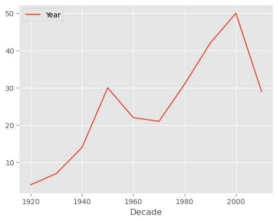

```python
# We'll learn how to make plots like this in the next lecture!
imdb.groupby('Decade').count().plot(y='Year');
```

### Question: What was the highest rated movie of the 1990s?

Let's try to do this two different ways.

#### Without grouping

```python
imdb[imdb.get('Decade') == 1990].sort_values('Rating', ascending=False).index[0]
```

```
'The Shawshank Redemption'
```

*Note:* The command to extract the index of a DataFrame is `.index` - no parentheses! This is different than the way we extract columns, with `.get()`, because the index is not a column.

#### With grouping

```python
imdb.reset_index().groupby('Decade').max()
```

| Decade | Title | Votes | Rating | Year |
| --- | --- | --- | --- | --- |
| 1920 | The Kid | 98794 | 8.3 | 1927 |
| 1930 | The Wizard of Oz | 259235 | 8.5 | 1939 |
| 1940 | The Treasure of the Sierra Madre | 350551 | 8.6 | 1949 |
| ... | ... | ... | ... | ... |
| 1990 | Unforgiven | 1498733 | 9.2 | 1999 |
| 2000 | Yip Man | 1473049 | 8.9 | 2009 |
| 2010 | X-Men: Days of Future Past | 1271949 | 8.7 | 2015 |

10 rows × 4 columns

- It turns out that this method **does not** yield the correct answer.
- When we use an aggregation method (e.g. `.max()`), aggregation is done to each column individually.
- While it's true that the highest rated movie from the 1990s has a rating of 9.2, that movie is **not** Unforgiven – instead, Unforgiven is the movie that's the latest in the alphabet among all movies from the 1990s.
- Taking the `max` is not helpful here.

### Question: How many years have more than 3 movies rated above 8.5?

**✅ Click **here** to see the answer.**

```
good_movies_per_year = imdb[imdb.get('Rating') > 8.5].groupby('Year').count()
good_movies_per_year[good_movies_per_year.get('Votes') > 3].shape[0]
```

As mentioned below, you can also use:

```
(good_movies_per_year.get('Votes') > 3).sum()
```

#### Aside: Using `.sum()` on a boolean array

- Summing a boolean array gives a count of the number of `True` elements because Python treats `True` as 1 and `False` as 0.
- Can you use that fact here?

### Question: Out of the years with more than 3 movies, which had the highest average rating?

**✅ Click **here** to see the answer.**

```
more_than_3_ix = imdb.groupby('Year').count().get('Votes') > 3
imdb.groupby('Year').mean()[more_than_3_ix].sort_values(by='Rating').index[-1]
```

### Question: Which year had the longest movie titles, on average?

**Hint:** Use `.str.len()` on the column or index that contains the names of the movies.

**✅ Click **here** to see the answer.**

```
(
    imdb.assign(title_length=imdb.index.str.len())
    .groupby('Year').mean()
    .sort_values(by='title_length')
    .index[-1]
)
```

The year is 1964 – take a look at the movies from 1964 by querying!

### Question: What is the average rating of movies from years that had at least 3 movies in the Top 250?

**✅ Click **here** to see the answer.**

```
# A Series of Trues and Falses; True when there were at least 3 movies on the list from that year
more_than_3_ix = imdb.groupby('Year').count().get('Votes') > 3

# The sum of the ratings of movies from years that had at least 3 movies on the list
total_rating = imdb.groupby('Year').sum()[more_than_3_ix].get('Rating').sum()

# The total number of movies from years that had at least 3 movies on the list
count = imdb.groupby('Year').count()[more_than_3_ix].get('Rating').sum()

# The correct answer
average_rating = total_rating / count

# Close, but incorrect:
# Doesn't account for the fact that different years have different numbers of movies on the list
close_but_wrong = imdb.groupby('Year').mean()[more_than_3_ix].get('Rating').mean()
```

## Summary, next time

### Summary

- We can write queries that involve multiple conditions, as long as we:
  - Put parentheses around all conditions.
  - Separate conditions using `&` if you require all to be true, or `|` if you require at least one to be true.
- The method call `df.groupby(column_name).agg_method()` **aggregates** all rows with the same value for `column_name` into a single row in the resulting DataFrame, using `agg_method()` to combine values.
  - Common aggregation methods include `.count()`, `.sum()`, `.mean()`, `.median()`, `.max()`, and `.min()`.

### Next time

A picture is worth a 1000 words – it's time to visualize!